# Analysis of Mean Values

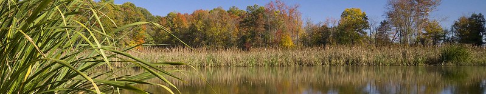

The analysis of mean values can be applied to single vectors of data, to pairs of data, and to a multitude of observed measurements.

# The Data

For this homework, we are looking at the data from the Rice Rivers Center. Here we will be testing individual, pairs, and complete sets of mean values using `t.test` and `aov` values. Start by loading in the raw data using the function that you’ve already made to format it properly.

## Questions

For the following questions, answer using statistics, graphs, tables, or whatever you need to properly address the question being asked. *Make sure to specifically state which $H_O$ you are actually testing.*

1. Test the null hypothesis that the average overnight air temperatures (say between 7am & 7pm) on all Mondays in January & February were above freezing. *Describe your results verbally with the aid of the statistics, visualization, or whatever you feel will help you make your point*.
2. Are weekend water temperatures in February warmer than weekend air temperatures? *Describe your results verbally with the aid of the statistics, visualization, or whatever you feel will help you make your point*.
3. Are there differences in the average rain recorded each weekeay at the Rice Rivers Center? *Describe your results verbally with the aid of the statistics, visualization, or whatever you feel will help you make your point*.